# findPvalueCutoff

Vijaykumar Yogesh Muley

Instituto de Neurobiología, Universidad Nacional Autónoma de México, Querétaro, Mexico

vijay.muley@gmail.com

2021-07-23

# 1 Introduction

Cells respond to external and internal signals by controlling expression of specific genes that process the signals and generate adaptive responses (Muley and Pathania 2017). Several experimental techniques have been developed to quantify expression of genes at genome scale. This process is often referred to as gene expression profiling or transcriptomics (Pathania and Muley 2017). The common theme of such experiments is to obtain gene expression profiles from control (normal) samples and experimental samples with specific treatment or from diseased individuals in replicates (Law et al. 2016). Then, the expression of each gene is compared between experimental and normal samples. Genes with significant expression changes in the experimental group compared to normal are more likely to be responsible for the phenotypic differences between the groups. These genes are referred to as differentially expressed genes. Such analyses are also commonly used in studying developmental time points to understand which genes are required for specific developmental time points (Muley et al. 2020).

## 1.1 Differential gene expression analysis

Several statistical tools have been developed to perform differential expression analysis (Rapaport et al. 2013; Robinson and Oshlack 2010; Soneson and Delorenzi 2013). These tools typically perform hypothesis significance testing under a null hypothesis that the gene has no differential expression in the compared group and assign a test p-value to a gene. The p-value is the probability of obtaining test results as extreme as the results observed when the null hypothesis is correct. A very small p-value means that such an extreme observed outcome would be very unlikely under the null hypothesis, and hence the gene has different expression in compared groups. Conventionally, the null hypothesis is rejected at p-value threshold of 0.05 or less and the gene would be considered to have significant differential expression in two groups. Since differential expression analysis involves hypothesis testing for thousands of genes, the resulting p-values need to be adjusted (corrected) for multiple hypothesis testing. Most often Benjamin and Hochberg approach is used to adjust p-values resulting from differential expression analysis (Benjamini and Hochberg 1995). Then, genes with adjusted p-value 0.05 or less are considered differentially expressed. There is a great debate on whether 0.05 p-value cutoff should be used (Amrhein and Greenland 2018) and on p-value adjustment for multiple hypothesis testing (Colquhoun 2014; Perneger 1999). Sample sizes of the compared groups affect the generated p-values and hence conventional p-value cutoff may not be appropriate. To circumvent these problems, I proposed a method which estimates the false positive error rate at the specific p-value cutoff i.e. given a p-value threshold how many genes are expected to be falsely identified as differentially expressed.

## 1.2 Implementation

Let’s assume that we have a vector of unadjusted p-values assigned to genes from a differential expression analysis. These original p-values can be used to create a random dataset (control experiment) by shuffling their order in a vector. Technically, it is called a permutation resample and the technique is called permutation resampling (Chihara and Hesterberg 2018). The original p-value vector and the permutation resample can be used to compute how many genes are expected to be identified as differentially expressed by chance alone at a specific p-value threshold. Let’s assume that the p-value threshold is set to 0.05. I count how many genes have 0.05 or less p-values in the original p-value vector and consider them as true positives. Then, I count how many of these true positive genes assigned p-value 0.05 or less in a permutation resample. Since these genes are assigned p-values 0.05 or less even after randomization, I consider them false positives. The ratio of false positives to true positives represents the false positive error rates i.e. the number of genes that are expected to be differentially expressed by chance alone at 0.05 p-value cutoff. To get a robust estimate, permutation resampling is repeated 10000 times to create random datasets of original p-values. This gives rise to a 10000 false positive error rate at 0.05 p-value cutoff and forms a permutation distribution. The mean of the permutation distribution is used as a representative false positive error rate at 0.05 in detecting differentially expressed genes. In practice, false positive error rates are calculated at a series of p-value cutoffs. The p-value at which error rate is five percent or less would be a good threshold to select differentially expressed genes i.e. 95 percent confidence level. I have implemented this simulation-based permutation resampling technique in the R package referred to as *findPvalueCutoff*. The advantage with using **findPvalueCutoff** is that the p-value cutoff is predicted based on distribution of p-values itself by randomizing their order. This data-driven approach avoids using arbitrary cutoff of 0.05 p-value, and particularly useful when thousands of genes appear differentially expressed when sample sizes are large. In the subsequent text, the details are presented on how to compute false discovery rate at various p-value cutoff using **findPvalueCutoff** function, and selection of differentially expressed genes.

## 1.3 Contact

For questions regarding **findPvalueCutoff**, contact the author at *vijay.muley@gmail.com*

# 2 INSTALLATION

Few R packages are required to install **findPvalueCutoff**. These can be installed by executing following chunk of code in R. In principle, only **devtools** package is required to install **findPvalueCutoff**. But other packages build ready to use documentation about running and working with findPvalueCutoff. For Windows operating system, RTools software should be already installed. Windows users can download and install RTools from [here](https://cran.r-project.org/bin/windows/Rtools/).

```r
if (!requireNamespace("BiocManager", quietly = TRUE))
    install.packages("BiocManager")
if (!requireNamespace("BiocStyle", quietly = TRUE))
    BiocManager::install("BiocStyle")
if (!requireNamespace("knitr", quietly = TRUE))
    install.packages("knitr")
if (!requireNamespace("rmarkdown", quietly = TRUE))
    install.packages("rmarkdown")
if (!requireNamespace("devtools", quietly = TRUE))
    install.packages("devtools")
```

Then, install **findPvalueCutoff** package from the github repository as shown below.

```r
devtools::install_github("vijaykumarmuley/findPvalueCutoff", build_vignettes = TRUE)
```

In case having trouble, you can run above command by setting build_vignettes to FALSE.

Once install, load **findPvalueCutoff** into your workspace:

```r
library(findPvalueCutoff)
```

Note that this command must be run every time you restart R in order to be able to use the package. To get immediate help on **findPvalueCutoff**, type:

```r
?findPvalueCutoff
```

**findPvalueCutoff** function needs a vector of uncorrected p-values resulting from differential gene expression analysis tools. Some parameters need to be adjusted and details are given below.

# 3 Estimating false positive rates at various p-value cutoffs

I will use example data of differential expression provided with the package, which was obtained from my previous published work (Muley et al. 2020). It contains output typically generated by differential gene expression analysis tools such as limma, edgeR or DESeq (Rapaport et al. 2013; Soneson and Delorenzi 2013). The following command will load the data which is a data.frame named pvalue. Please note that there should not be any object with name pvalue in current R environment. Otherwise, it will be replaced with the pvalue object from this package.

```r
data(pvalue)
```

To check first few lines of the data, you can type following commands

```r
head(pvalue)
```

```
#>                       logFC  AveExpr        t      P.Value    adj.P.Val
#> ENSMUSG00000032446 4.512662 5.119289 30.38802 4.581155e-12 5.349873e-08
#> ENSMUSG00000010505 3.760632 5.272638 27.08535 1.623325e-11 9.478597e-08
#> ENSMUSG00000041911 2.984226 4.981805 23.49275 7.717584e-11 3.004198e-07
#> ENSMUSG00000036306 2.501910 5.373344 19.93014 4.629336e-10 9.809627e-07
#> ENSMUSG00000033740 5.002689 3.895736 20.09526 4.232737e-10 9.809627e-07
#> ENSMUSG00000022053 3.993880 3.656121 19.77461 5.040055e-10 9.809627e-07
#>                           B  gene                                    genename
#> ENSMUSG00000032446 17.81065 Eomes                                eomesodermin
#> ENSMUSG00000010505 16.85906  Myt1               myelin transcription factor 1
#> ENSMUSG00000041911 15.42690  Dlx1                      distal-less homeobox 1
#> ENSMUSG00000036306 13.74247 Lzts1 leucine zipper, putative tumor suppressor 1
#> ENSMUSG00000033740 13.49772  St18            suppression of tumorigenicity 18
#> ENSMUSG00000022053 13.38696  Ebf2                       early B cell factor 2
```

There are two ways to run **findPvalueCutoff**. 1) use a vector of predefined p-value cutoffs (manually selected set) or 2) set a lower and upper range and choose an interval so that this function generates a series of p-value cutoffs from lower to upper bound by incrementing lower bound with desired number that provided using interval parameter. I demonstrated both ways with example data below.

## 3.1 Using predefined p-value thresholds

**findPvalueCutoff** function generates random samples of the input p-values. Hence, the output would be a little bit different with each run on the same data. Therefore, I first set a seed to a random number using the set.seed function to reproduce the same results. Then I run **findPvalueCutoff** by setting up:

1. x paramater to differential expression values from the column *P.Value* in the pvalue data.frame,
2. thresholds parameter to manually selected p-value cutoffs at which I would like to compute false positive rates,
3. nsims parameter to 100 to create 100 randomized datasets from the given p-values

In practice, I recommend setting nsims value to at least 1000, and best would be to set 10000 for accurate results.

After setting these parameters, I run **findPvalueCutoff** function and store its output in fdr object.

```r
set.seed(1979)
fdr <- findPvalueCutoff(x = pvalue$P.Value, thresholds = c(0.0001, 0.001, 0.01, 0.1, 0.15, 0.2), nsims = 100)
```

As shown below the fdr object is a numeric vector containing false positive rates in percentages computed at a given series of p-value cutoffs, which are names of the elements in the fdr object. For instance, approximately 5 percent of the differentially expressed genes are likely to be falsely detected by chance alone at the p-value cutoff of 0.001 i.e. 95% confidence level would be achieved in detecting differentially expressed genes if applied to the 0.001 p-value cutoff.

```r
fdr
```

```
#>     1e-04     0.001      0.01       0.1      0.15       0.2
#>  2.563427  4.957118  9.096970 18.373228 21.323553 23.694279
```

Let’s compare how many genes are differentially expressed using conventional cutoff of 0.05 after adjusted p-values, and the 0.001 cutoff on unadjusted p-values suggested by **findPvalueCutoff** function.

```r
sum(pvalue$adj.P.Val<=0.05)
```

```
#> [1] 2087
```

```r
sum(pvalue$P.Value<=0.001)
```

```
#> [1] 1166
```

As shown above, 2087 genes were identified as differentially expressed using conventional p-value cutoff, while only 1166 genes are differentially expressed according to p-value cutoff estimated by **findPvalueCutoff** function. The expected detection error rate at this cutoff is close to five percent of the total identified genes.

These results can be plotted as follows and can be saved for later use.

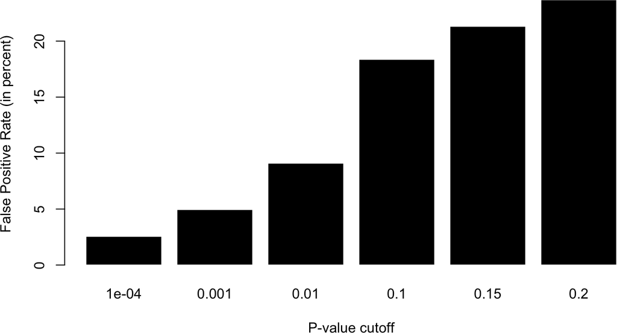

Figure 1: False positive error rates predicted from random datasets according to the uncorrected differential expression p-values  
The false positive error rate represents the ratio of the number of significant p-values from the randomized dataset (control experiment) to the number of significant p-values from the real dataset below a certain p-value. False positive error rate is close to 5 percent at p-value cutoff of 0.001.

```r
barplot(fdr, names = names(fdr), col =  "black", border = "white", xlab = "P-value cutoff", ylab = "False Positive Rate (in percent)")
```

The plot shows the false positive rate is close to five at 0.001 p-value cutoff. This should be used for selecting differentially expressed genes.

## 3.2 Using a range of p-values at specific interval

**findPvalueCutoff** provide two more parameters to quickly get an idea about false positive rates at a series of p-value cutoffs. This can be done by running with following parameters.

1. x paramater to differential expression values from the column *P.Value* in the pvalue data.frame,
2. range parameter to provide a lower and upper bound of the p-values,
3. interval parameter to a number to increment lower bound of the p-value progressively until upper bound provided with range parameter,
4. nsims parameter to 100 to create 100 randomized datasets from the given p-values

In this example, I set range between 0 to 0.2 with interval 0.02, and execute the function as shown below,

```r
set.seed(1979)
fdr <- findPvalueCutoff(x = pvalue$P.Value, range = c(0, 0.2), interval = 0.02, nsims = 100)
```

These results can be plotted as follow

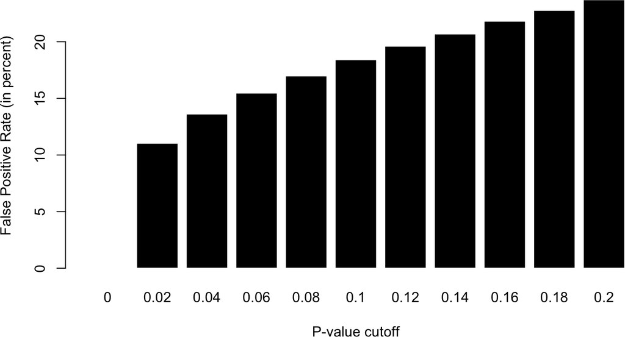

Figure 2: False positive error rates predicted from random datasets according to the uncorrected differential expression p-values  
The false positive error rate represents the ratio of the number of significant p-values from the randomized dataset (control experiment) to the number of significant p-values from the real dataset below a certain p-value. This plot gives an idea that false positive error rate is five percent or less between p-values 0 to 0.02. One can now use p-values between this range to get more finer false positive rate and corresponding p-value cutoff.

```r
barplot(fdr, names = names(fdr), col =  "black", border = "white", xlab = "P-value cutoff", ylab = "False Positive Rate (in percent)")
```

Plot shows that a false positive rate of 5 is estimated between the range of 0 and 0.02 p-value cutoffs. This range can be used to get a finer false positive rate and the corresponding p-values.

# 4 References

Amrhein, Valentin, and Sander Greenland. 2018. “Remove, Rather than Redefine, Statistical Significance.” Nature Human Behaviour 2 (1): 4. https://doi.org/10.1038/s41562-017-0224-0.

Benjamini, Yoav, and Yosef Hochberg. 1995. “Controlling the False Discovery Rate: A Practical and Powerful Approach to Multiple Testing.” Journal of the Royal Statistical Society: Series B (Methodological) 57 (1): 289–300. https://doi.org/10.1111/j.2517-6161.1995.tb02031.x.

Chihara, Laura M., and Tim C. Hesterberg. 2018. Mathematical Statistics with Resampling and R. Mathematical Statistics with Resampling and R. Hoboken, NJ, USA: John Wiley & Sons, Inc. https://doi.org/10.1002/9781119505969.

Colquhoun, David. 2014. “An Investigation of the False Discovery Rate and the Misinterpretation of P-Values.” Royal Society Open Science 1 (3): 140216. https://doi.org/10.1098/rsos.140216.

Law, Charity W., Monther Alhamdoosh, Shian Su, Gordon K. Smyth, and Matthew E. Ritchie. 2016. “RNA-Seq Analysis Is Easy as 1-2-3 with Limma, Glimma and EdgeR.” F1000Research 5 (November): 1408. https://doi.org/10.12688/f1000research.9005.2.

Muley, Vijaykumar Yogesh, Carlos Javier López-Victorio, Jorge Tonatiuh Ayala-Sumuano, Adriana González-Gallardo, Leopoldo González-Santos, Carlos Lozano-Flores, Gregory Wray, Maribel Hernández-Rosales, and Alfredo Varela-Echavarría. 2020. “Conserved and Divergent Expression Dynamics during Early Patterning of the Telencephalon in Mouse and Chick Embryos.” Progress in Neurobiology 186 (March). https://doi.org/10.1016/j.pneurobio.2019.101735.

Muley, Vijaykumar Yogesh, and Amit Pathania. 2017. “Gene Expression.” In: Vonk J., Shackelford T. (Eds) Encyclopedia of Animal Cognition and Behavior. Springer, Cham. https://doi.org/10.1007/978-3-319-47829-6_49-2.

Pathania, Amit, and Vijaykumar Yogesh Muley. 2017. “Gene Expression Profiling.” In: Vonk J., Shackelford T. (Eds) Encyclopedia of Animal Cognition and Behavior. Springer, Cham. https://doi.org/10.1007/978-3-319-47829-6_9-1.

Perneger, Thomas V. 1999. “Adjusting for Multiple Testing in Studies Is Less Important than Other Concerns.” BMJ 318 (7193): 1288–1288. https://doi.org/10.1136/bmj.318.7193.1288a.

Rapaport, Franck, Raya Khanin, Yupu Liang, Mono Pirun, Azra Krek, Paul Zumbo, Christopher E Mason, Nicholas D Socci, and Doron Betel. 2013. “Comprehensive Evaluation of Differential Gene Expression Analysis Methods for RNA-Seq Data.” Genome Biology 14 (9): 3158. https://doi.org/10.1186/gb-2013-14-9-r95.

Robinson, Mark D, and Alicia Oshlack. 2010. “A Scaling Normalization Method for Differential Expression Analysis of RNA-Seq Data.” Genome Biology 11 (3): R25. https://doi.org/10.1186/gb-2010-11-3-r25.

Soneson, Charlotte, and Mauro Delorenzi. 2013. “A Comparison of Methods for Differential Expression Analysis of RNA-Seq Data.” BMC Bioinformatics 14 (1): 91. https://doi.org/10.1186/1471-2105-14-91.